# Algorithm Class 14 - Lecture 6

Heap & Graph Search Algorithms I

June/12/2019

# 1 Heap

Heap (or min/max heap) (堆), is also called Priority Queue (優先隊列).

Purpose: Maintain an **optimal value** for a continuously **changing** data set.

## 1.1 Example

```
      1
    /   \
  2       3
 / \     / \
5   4   7  null

index: 0 1 2 3 4 5
value: 1 2 3 5 4 7

left_index = parent_index * 2 + 1
right_index = parent_index * 2 + 2
```

## 1.2 Property of Heap

Nature: The heap is implemented by constructing a binary heap (二叉堆). This data structure has the following properties.

1. Heap is always a complete binary tree (完全二叉樹).
2. Heap Order (堆序性): Any node is less than all its descendents (後裔).

The heap which the root value is the smallest is called a MIN HEAP (最小堆). The heap which the root value is the largest is called a MAX HEAP (最大堆).

### 1.2.1 Implement by an array

Implemented as an unsorted array:

1. index of lChild = my index * 2 + 1
2. index of rChild = my index * 2 + 2
3. index of parent = (my index - 1) / 2

## 1.3 Operation of Heap

1. `insert(e)`: Insert a new element into the heap. Time: O($\log(n)$) (percolate Up)

```
insert(0)

      1
    /   \
  2       3
 / \     / \
5   4   7  null

---

      1
    /   \
  2       3
 / \     / \
5   4   7   0

---

      1
    /   \
  2       0
 / \     / \
5   4   7   3

---

      0
    /   \
  2       1
 / \     / \
5   4   7   3
```

2. `update(e1, e2)`: Update a new element and match it with the nature of the heap. Time: O($\log(n)$)

```
update(2, 8)

      1
    /   \
  2       3
 / \     / \
5   4   7  null

---

      1
    /   \
  8       3
 / \     / \
5   4   7  null

---

change 8 with its smaller child, which is 4

      1
    /   \
  4       3
 / \     / \
5   8   7  null
```

3. `getTop()`: Get the value of the current root element. Time: O($1$)
4. `pop()`: Delete the root element. Time: O($\log(n)$) (percolate Down)

```
pop()

      1
    /   \
  2       3
 / \     / \
5   4   7  null

---

    null
    /  \
  2      3
 / \    / \
5   4  7  null

---

      7
    /   \
  2       3
 / \     / \
5   4   n   n

---

      2
    /   \
  7       3
 / \     / \
5   4   n   n

---

      2
    /   \
  4       3
 / \     / \
5   7   n   n
```

5. `heapify()`: Make an unsorted array into a heap. Time: O($n$)
   - https://en.wikipedia.org/wiki/Heapsort

## 1.4 Problem: Smallest k Elements of an Array

Find **smallest** k elements from an unsorted array of size n.

**Solution 0:** Sort

- Time: O($n\log(n)$)

**Solution 1:** Min heap

- Step 1: Heapify. Time: O($n$)
- Step 2: Call pop() k times. Time: O($k\log(n)$)
- Total time: O($n+k\log(n)$)

**Solution 2:** size == k max heap (to store the smallest k candidates)

- Step 1: Heapify the first k elements. Time: O($k$)
- Step 2: Iterate through the remaining (n-k) elements. For each element, compare it with the root of the heap:
  - Case 1: If value >= root, ignore
  - Case 2: If value < root, update (root -> new element)
- Step 3: Finally, all elements remaining in this heap is the result to return.
- Total time: O($k+(n-k)\log(k)$)

```
Example:

- k = 7
- n1, n2, n3, n4, n5, n6, n7, n8, n9, n10, ...
```

```
[n1 n2 n3 n4 n5 n6 n7] n8 n9 n10 ...

n1 ~ n7:
      x <- max
    /   \
  x       x
 / \     / \
x   x   x   x

scan from n8
- if larger than top, ignore
- if smaller than top, update
```

Solution 2 is an online algorithm, Solution 1 is an offline algorithm.

**Solution 3:** Quick select

```
n = 1000
k = 20

xxxP3xxxxxxxxxxP2xxxxxxxxxxxxxxP1xxxxxxxxxxxxxxxxxx
 3      195            ...              500
```

- Average time: O($n+n/2+n/4+\cdots$) = O($n$)
- Worst case time: O($n+(n-1)+(n-2)+\cdots+1$) = O($n^2$)

Solution 3 is an offline algorithm.

# 2 Graph

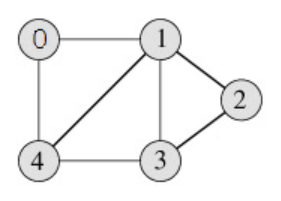

```
<01> <14> <23> <13> <04> ...
```

1. Node

2. Edge

3. Directed v.s. undirected graph

4. Representation of the graph

- Adjacency Matrix
  - Pros: Representation is easy to implement. Edge removal takes O($1$) time. Queries like whether there is an edge from vertex “u” to vertex “v” are efficient and can be done O($1$).
  - Cons: Consumes more space, O($V^2$). (V is the number of vertex/node.) Even if the graph is sparse (contains less number of edges), it is still waste of space.

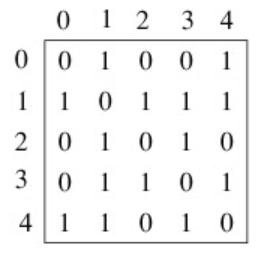

- Adjacency List
  - Pros: Space complexity = O($|V|+|E|$). Adding a vertex/node to the graph is easier.
  - Cons: Time complexity is O($V$) to check whether there is an edge from a node to the other (compared to O($1$) in adjacent matrix).

```
0 -> 1 -> 4
1 -> 0 -> 4 -> 3 -> 2
2 -> 1 -> 3
3 -> 1 -> 4 -> 2
4 -> 3 -> 0 -> 1

Vertices/nodes: |V|
Edges: |E|
```

```java
class GraphNode {
  List<GraphNode> neighbors;
}
```

# 3 Graph Search Algorithms

## 3.1 Breadth-First Search, (寬度優先搜索) (BFS-1)

```
        1
      /   \
    3       2
   / \     /
  5   4   7
 / \
9  11
```

Operation processes of BFS & How to describe a BFS action during an interview?

- **Data Structure:** Maintain a **FIFO queue**, put all traversed nodes that haven’t been expanded.

```
expand 1, generate 3 and then 2 into the queue:
head {3, 2} tail
```

- **Expand** a node, visit/print its value.
- **Generate** its neighbor nodes: reach out to its neighboring nodes.
- **Termination condition:** do a loop until the queue is empty.
- Optionally **deduplicate** visited nodes (typically for graph not for tree).
  - e.g. each node is expanded only once
  - e.g. each node is generated only once

### 3.1.1 Problem 1: Layered Print a Binary Tree

```
        1      expand(1) -> generate(3), generate(2)
      /   \
    3       2  expand(3) -> generate(5), generate(4)
   / \     /   expand(2) -> generate(7)
  5   4   7    expand(5) -> generate(9), generate(11)
 / \           expand(4) -> generate nothing
9  11          expand(7) -> generate nothing
               expand(9) -> generate nothing
               expand(11) -> generate nothing

Queue = -<- {    } -<-
```

```
1 newline
3 2 newline
5 4 7 newline
9 11 newline
```

```
Queue {1}
size == 1

expand(1), generate(3), generate(2)
newline
Queue {3, 2}
size == 2

expand(3), generate(5), generate(4)
newline
expand(2), generate(7)
Queue {5, 4, 7}
size == 3
```

- Data Structure: FIFO queue
- Algorithm: BFS-1
- Initialization: queue = {root}
- For each step:
  1. Record the size (= k) of the queue
  2. k times of expand and generate

```java
public void BFS(Node root) {
  if (root == null) {
    return;
  }
  Queue<Node> q = new LinkedList<Node>();
  q.offer(root);
  while (!q.empty()) {
    int size = q.size();  // size = # of nodes in the current layer
    for (int i = 0; i < size; i++) {
      Node n = q.remove();  // expand
      if (n.left != null) {
        q.offer(n.left);  // generate left
      }
      if (n.right != null) {
        q.offer(n.right); // generate right
      }
      System.out.print(n.val + " ");
    }
    System.out.println();
  }
}
```

- Time: O($n$)
- Space: O($n$)

### 3.1.2 Problem 2: Bipartite

Whether a graph’s node can be divided into two groups, such that the nodes in each group do not have direct edges between the nodes that belong to the same group.

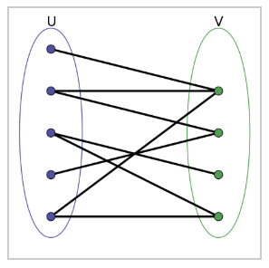

```
1 (u) --- 2 (v) --- 4 (u)
 |         |
3 (v) --- 5 (u)

1 -> u
2, 3 -> v
4 -> u
```

```java
class GraphNode {
  int value;
  char set; // u or v
  List<GraphNode> succesors;
}
```

- Data structure: FIFO queue
- Initialize: enqueue 1, color 1 with u
- For each step:
  1. Expand: dequeue the first element (x) of the queue
  2. Generate: enqueue all the neighbors (y) and color them with the other color
     1. Case 1: y is generated before
        1. Case 1.1: y’s color is different from x’s color, ignore (dedup)
        2. Case 1.2: y’s color is the same as x’s color, CONFLICT!
     2. Case 2: y is not generated before
        1. color y with the other color than x
- Terminate: queue is empty or when there’s a conflict
- Dedup: record each node’s color (empty, u, v)

O(n) extra space

```
1 (u) --- 2 (v) --- 4 (u)
    \     /
     3 (v)

Step 1: expand 1 (u) -> generate 2 (v) and 3 (v)
Step 2: expand 2 (v) -> generate all the neighbors of 2 (1, 3, 4)
- Case 1: not generated (e.g. 4), color it with other color: 4 (u)
- Case 2: generated before
    - if the neighbor has the other color (e.g. 1), ignore
    - if the neighbor has the same color (e.g. 3), return false
```

### 3.1.3 Problem 3: Whether a binary tree is complete?

Determine whether a binary tree is a complete binary tree.

```
        1      expand 1 -> generate 3 2
      /   \
    3       2  expand 3 -> generate 5 4
   / \     /   expand 2 -> generate 7 null
  5   4   7    expand 5 -> try to generate 9 but...
 / \
9  11

Queue = {1}
Queue = {3, 2}
Queue = {2, 5, 4}
Queue = {5, 4, 7, null}

boolean flag = false;
if (generate null) {
  flag = true;
}
```

BFS: expand + generate

- Case 1: left = null, right = non-null, return false
- Case 2: After detecting the first node that misses one child, then check whether all following nodes expanded to see whether they have any node generated (if any -> then false)

## 3.2 Discussion

Can we use BFS1 for the shortest path problem?

- If all edge costs in the graph are uniform (e.g. all 1s), then in this special case, we can use BFS1 to find the shortest path. Otherwise, BFS1 is not the correct algorithm.

## 3.3 Best First Search (BFS-2)

經典算法: Dijkstra’s Algorithm (runtime efficiency improvement: A* algorithm, https://en.wikipedia.org/wiki/A*_search_algorithm)

1. **Usages:** Find the shortest path cost from a single node (source node) to **any other nodes** in that graph (點到面/所有點的最短距離算法)
2. Example problem: 從北京到中國其他所有主要城市的最短距離是多少?
3. **Data structure:** **priority_queue** (MIN_HEAP)

### 3.3.1 Breakdown

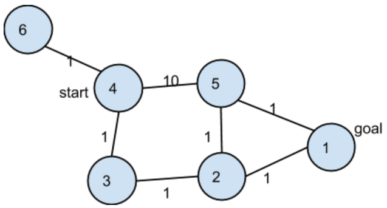

1. Initial state
2. while() expansion/generation rule
   - Expand a node
   - Generate all neighbors
3. Termination condition

```
4

---

Priority Queue:
{3, 1}
{5, 10}
{6, 1}

Expand the shortest: 3 or 6 are all fine since they have same distance

===

Say expand 6
{3, 1}
{5, 10}

Expand 3

===

{2, 2} the distance is the sum of 1 + 1
{5, 10}

Expand 2

===

{1, 3}
{5, 10}
{5, 3}

---

or just update 10 to 3
{1, 3}
{5, 3}

Expand 5

===

{1, 3}
{1, 4}
```

Algorithm:

1. Initialize: enqueue `<the source code, 0>`
2. For each step:
   1. Expand:
      - dequeue the node (x) with the smallest distance from the source - O($\log(n)$)
      - dedup: if x has been expanded before, don’t generate anything
   2. Generate:
      - enqueue all neighbors `<the neighbor, dist(x) + weight(x->y)>` - O(# of outgoing edges * $\log(n)$)
      - if (dist(x) + weight(x->y) >= dist(y)), ignore
      - if (dist(x) + wright(x->y) < dist(y)), enqueue
   3. Terminate: the queue is empty
   4. Dedup: each node is expanded only once

### 3.3.2 解題思路

1. Initial state (start node)
2. Node expansion/generation rule
3. Termination condition: 所有點都計算完畢才停止, 也就是queue變空

### 3.3.3 Example

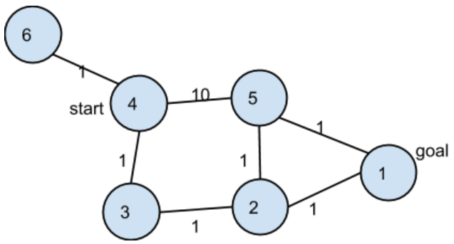

Start node is 4.

cost(node) = cost(parent of node) + cost(parent of node, node), e.g. cost(2) = cost(3) + cost(3, 2) = 1 + 1 = 2

cost(4, 5) = 10

Cost for all the rest edges = 1

Step 0 (initial state): No nodes have been expanded.

- Node(4, 0)

Step 1: Pop node (4, 0) out of the queue, expand node(4, 0) and generate three successors:

- Node(5, 10)
- Node(3, 1)
- Node(6, 1)

Step 2: Pop node (6, 1), generate nothing. queue = {Node(5, 10), Node(3, 1)}

Step 3: Pop node (3, 1), generate node (2, 2). queue = {Node(5, 10), Node(2, 2)}

Step 4: Pop node (2, 2), generate:

1. re-generate node (5, 10) -> node (5, 2+1) -> node (5, 3)
2. generate node (1, 3)

Step 5: …

Until the queue is empty, then we terminate.

### 3.3.4 Property of BFS-2

1. One node can be expanded once and only once
2. One node can be generated more than once. (cost can be reduced over time)
3. All the cost of the nodes that are expanded are monotonically non-decreasing (所有cost都是單調遞增)
4. Time complexity, for a graph with n node and the connectivity of the node is constant (e.g. 4-connected grid), http://en.wikipedia.org/wiki/Dijkstra%27s_algorithm, O($n\log(n)$). For general graph, O($(V+E)\log(V)$)=O($E\log(V)$)
5. When a node is popped out for expansion, its value is fixed which is equal to the shortest distance from the start node.

### 3.3.5 Variant

1. How to find the shortest path between a pair of node.
   - Termination condition: when the target node is expanded.

## 3.4 經典考題 (運用Dijkstra’s Algorithm的性質)

Given a matrix of size NxN, for each row the elements are sorted in an ascending order, and for each column the elements are also sorted in an ascending order. How to find the k-th smallest element in it?

```
1   2   3   5   6
2   3   4   6   8
3   4   5   7   9
4   5   6   8  10
5   6   9  10  11

k = 7, return 4
k = 10, return 5
```

BFS2:

1. Initial state: array[0][0]
2. Expansion/generation rule: expand node [i][j], generate node node [i+1][j] and node node [i][j+1]
3. Termination condition: when the k-th element is expanded (popped out of the priority queue)
4. Deduplication: record which nodes have been generated, boolean[][] generated = true

For each layer, time = O(number of nodes) = O($\log(k)$). Total time: O($k\log(k)$)

Space: O($k+n^2$). If using Class 8 HashSet for deduplication, then the space can be reduced to O($k$).

## 3.5 Discussion

General algorithm for BFS{1, 2}:

1. **Initial state:** root node/start node/minimum number…
2. **Node expansion/generation rule:**
   1. BFS1: expand node, generate all neighbors -> FIFO queue
   2. BFS2: expand node, generate all neighbors -> Priority-queue (Heap)
3. **Termination condition:**
   1. Queue is empty
   2. When a conflict is found
   3. When the target node is expanded
   4. When the k-th element is expanded
4. **(Optional) Deduplication**

When should we consider to use BFS-1?

- Related to levels

When should we consider to use BFS-2?

- Shortest path
- k-th smallest/largest